# homework0

Physics 474 - Spring 2023

Homework 0 - Basic practice

Author: Dillon Walton

NOTE: These problems are for practicing with python and not necessarily the best way to do the programming

There are always many ways to do the code, and not just a "right" way. But, you need to do the coding within the rules and constraints I ask for. Thanks!

Problem 1a: (1pt)

Write a program with a single "for-loop" and "if...else..." that calculates BOTH

- The sum of integers from 1 to 100
- The sum of integers from 101 to 200

In that single loop. Print out the results

```python
# Problem 1a code here...
i = 1
x = 0
y = 0
for j in range(0,200,1):
    if i < 101:
        x += i
        # print(x)
    else:
        y += i
        # print(y)
    i += 1

print(f'final count 1 to 100: {x}')
print(f'final count 101 to 200: {y}')
```

```
final count 1 to 100: 5050
final count 101 to 200: 15050
```

Problem 1b: (2pt)

write a user defined function to calculate the sum of integers input as a parameter

print the sum of integers from 1 to n for:

- $10 \le n \le 50$

```python
# Problem 1b code here...

def sumOfIntegers(n):
    x = 0
    for i in range(1,n+1,1):
        x += i
        # print(x)
    print(f'Final sum: {x}')

sumOfIntegers(11)
```

```
Final sum: 66
```

Problem 2: (2pts)

Write a program that

- prompts the user for an integer $1 \le n\le 50$
- checks the input to be within range and responds appropriately
- uses a loop to calculate and print the factorial of the input number

```python
# Problem 2 code here...

def inputFactorial():
    num = int(input('Input number, 1 <= n <= 50, to calculate factorial with'))
    factorial = 1
    if num >= 1 and num <= 50:
        for i in range(1, num+1):
            factorial = factorial*i
        print(f'Factorial for {num} is {factorial}')
    else:
        raise Exception('Pick a number between 1 and 50 please')

inputFactorial()
```

```
Factorial for 2 is 2
```

Problem 3a: (2pts)

Write a program without NumPy that calulates $f(x) = x^2$ for $-3 \le x \le 3$ at x-spacing of $0.5$ and prints a table with 2 columns $x$ and $f(x)$

```python
# Problem 3a code here...
def f(x):
    return x**2

rng = [-3.0,-2.5,-2.0,-1.5,-1.0,-0.5,0,0.5,1.0,1.5,2.0,2.5,3.0]
table = []
for i in rng:
    table.append([i, f(i)])

print('| x | f(x) |')
for row in table:
    print('| {:1} | {:^4} |'.format(*row))
```

```
| x | f(x) |
| -3.0 | 9.0  |
| -2.5 | 6.25 |
| -2.0 | 4.0  |
| -1.5 | 2.25 |
| -1.0 | 1.0  |
| -0.5 | 0.25 |
| 0 |  0   |
| 0.5 | 0.25 |
| 1.0 | 1.0  |
| 1.5 | 2.25 |
| 2.0 | 4.0  |
| 2.5 | 6.25 |
| 3.0 | 9.0  |
```

Problem 3b: (2pts)

Repeat problem 3a using NumPy arrays

```python
# Problem 3b code here...
import numpy as np

def f(x):
    return x**2

rng = np.arange(-3,3.5,0.5)

table = []
for i in rng:
    table.append([i, f(i)])

print('| x | f(x) |')
for row in table:
    print('| {:1} | {:^4} |'.format(*row))
```

```
| x | f(x) |
| -3.0 | 9.0  |
| -2.5 | 6.25 |
| -2.0 | 4.0  |
| -1.5 | 2.25 |
| -1.0 | 1.0  |
| -0.5 | 0.25 |
| 0.0 | 0.0  |
| 0.5 | 0.25 |
| 1.0 | 1.0  |
| 1.5 | 2.25 |
| 2.0 | 4.0  |
| 2.5 | 6.25 |
| 3.0 | 9.0  |
```

Problem 3c: (1pt)

Make a simple plot of $f(x)$ vs. $x$

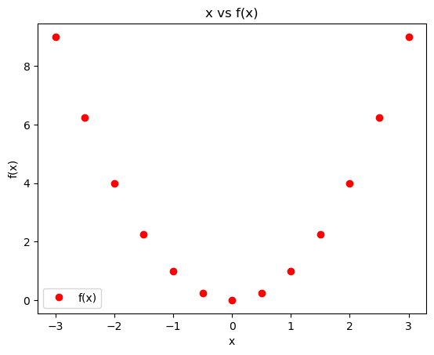

```python
# Problem 3c code here...
import matplotlib.pyplot as plt
import numpy as np

def f(x):
    return x**2

x = np.arange(-3,3.5,0.5)
y = []

for i in x:
    y.append(f(i))

plt.plot(x, y, 'o', color ='red', label ="f(x)")
plt.title('x vs f(x)')
plt.legend()
plt.xlabel('x')
plt.ylabel('f(x)')
plt.show()
```

Problem 4: (5pts)

write a program that generates 500 random numbers from a uniform distribution for $0\le x \le 10$ and 500 random numbers from a normal distribution with mean $\mu=0$ and width $\sigma=1$.

make 3 subplots on a 3x1 grid (3 rows) with

- histogram of the uniform distribution random numbers
- histogram of normal distribution random numbers
- scatter plot of normal randoms vs uniform randoms

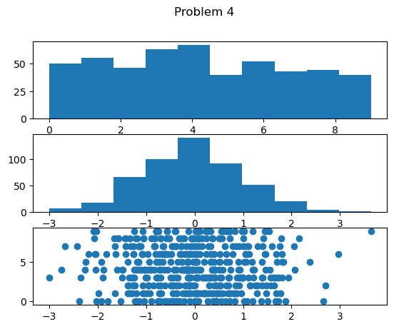

```python
# Problem 4 code here...
from numpy import random, mean, std
import matplotlib.pyplot as plt

x1=random.randint(10, size=(500))
x2=random.normal(size=500,loc=0,scale=1)

fig, axs = plt.subplots(3)
fig.suptitle('Problem 4')
axs[0].hist(x1)
axs[1].hist(x2)
axs[2].scatter(x2,x1)
```